# Bitcoin companies

The aim of the project is knowing the companies related to bitcoin which were dissolved since 17 December 2017.

Data was collecting using Companies House and OpenCorporates’s API. Different groups of words were used in each process to solve the APIs’ limitations. Words used:

CH: bitcoin, crypto, BTC, blockchain, cripto, coins, protocol, coinbase, coincheck, coindesk, coingate, bitgo, bitmoney, bitfinex, digitalmoney, buycoin, coinfloor,

OC: Satoshi, satoshipay, satoshicoins, satoshipoint, coin, ICO, digital currency, virtual currency, virtual money, bit trade, block (NOT INLCUDED IN THE FINAL ANALYSIS), ghash,magnr, Bsave, exmo finance.

Apart from that, I got 23 23 extra companies were included, those that appear on list of crypto currency companies and those which are part of the CryptoUK organisation.

```r
library(readxl)
library(tidyverse)
library(ggplot2)
library(lubridate)
library(scales)
```

# Importing datasets

```r
blockchain <- read.csv("blockchain.csv")
bitcoin <- read.csv("bitcoin.csv")
crypto <- read.csv("crypto.csv")
btc <- read.csv("btc.csv")
companies23 <- read.csv("company_data.csv")
```

```r
#Final analysis which will use companies23
CH <- read.csv("companiesCompanyHouse.csv")
OC <- read.csv("companiesOpenCorporates.csv")
```

# Cleaning names

Some words return results not related to bitcoins companies, so this require further cleaning. The words that have to be cleaned are: - CH: blockchain, coins, protocol - OC: coin and ICO.

For instance, “blockchain” is much more than the currency. It is also related to the technology. Having a look at the name of the companies, I identified some concept not likely to be connected to the digital money.

```r
rm(words)
words_blockchain <- c("TECH", "RESEARCH", "MEDIA", "SOCIAL", "ARTIFICIAL INTELLIGENCE", "AUTOMOTIVE", "ENERGY", "CARBON", "COMMUNICATIONS", "DATA", "DESIGN", "CONSTRUCTION", " AI ", "EDUCATION", "ENGINEERING", "SPORT", "FOREST", "REFUGEES", "FOR GOOD", "IMPROVEMENT", "INCUBATOR", "HARMONISED", "INFRASTRUCTURE", "INTELLIGENCE", "INNOVATI", "LAND", "PROPERTY", "SECURIT", "HEALTH", "INDUSTRIAL", "PHARMACY","ADVANCES", "APPAREL", "AUDITING", "CARE", "DEVELOP", "ENGINE"," IT ","LEGAL", "MOBILITY", "HOUSE", "SOFTWARE", "FOUDATION", "SMOKERS", "ART ", "ACADEMY", " LAB ", " LABS")
```

```r
no_blockchain <- CH %>% filter(word == "blockchain") %>% mutate(test = ifelse(previous_name=="Empty",grepl(paste(words_blockchain, collapse = "|"), name),grepl(paste(words_blockchain, collapse = "|"), previous_name))) %>% filter(test == TRUE)
```

Words that may go with coins in a bitcoin company

```r
words_coins <- c("ACCOUNTANCY","CHANGE","CHASE","CIRCLE","COINSCOPE","COINSEIGE","COINSEED","COINSHARES","COINS HARVEST","COINSHIRE","COINS HOUR","COINSIGHT FINANCIAL","COINSILIUM","COINSLIV","COINSMART","COINSNACK","COINSPRO", "COINSQUARE","COINS.SX","COINSTAMP","COINSTATION","COINSTEP","COINSTOCK","COINS TRADING","COINSTREAK","COINSTREAM","COINSCRYPT","COINS BEST","COINCASH PAYMENTS","COINSCRUM","NANOPAY","COINSULTING", "COINSCRUM","CEL.INT LTD","BTO COINS","BUBBLE AND COINS","THE COINS MARKET","COINSMITH","CONNOISSEUR","EVOLUTION COINS", "DIGIT","FUTURE COINS","GSG COINS","NRP COINS","PAY BY COINS","PENTUM COINS","NORMALIZE","S.A.R.L COINS WALLET","STARK COINS","SYNERGY COINS","24 COINS","VAP COINS","VENUS COINS","HULL COINS","DAILY","HOURLY","BCF","FORTUNA COINS","RAVEN COINS","COMMUNITY COINS","XCHANGE COINS","COINSTREAM","STAR COINS","COINSTABLE","COINSCRATCH")
```

```r
no_coins <- CH %>% filter(word == "coins") %>% mutate(test = ifelse(previous_name=="Empty",grepl(paste(words_coins, collapse = "|"), name),grepl(paste(words_coins, collapse = "|"), previous_name))) %>% filter(test == FALSE)
```

Words with protocol:

```r
words_protocol <- c("CAPITAL","COMPUT","FINANC","TRAD","VIRTUAL","EXCHANG")
```

```r
no_protocol <- CH %>% filter(word == "protocol") %>% mutate(test = ifelse(previous_name=="Empty",grepl(paste(words_protocol, collapse = "|"), name),grepl(paste(words_protocol, collapse = "|"), previous_name))) %>% filter(test == FALSE)
```

Words with ICO:

```r
words_ico <- c("LIEBSCHER","ACADEMY","CAMBRIDGESHIRE ","SATELLITE","GALLICO","FARM","HOUSING CARE","COMPETITION","HYBRID", "AWARDS","CATERING","CONSTRUCTION","CROWD","DESIGN","DIDSBURY","ELECTRICAL","ENERGY","ENTERTAINMENT","EVENT","INFORMATION", "MANAGEMENT","MASTER","RESEARCH","POLYMERS","SOFA","TOURIST","SOLUTIONS","STATIONERY","TECH","CULTURAL","SALON", "CONFERENCE","ZANAZ")
rm(test_words)
```

```r
no_ico <- OC %>% filter(word == "ICO") %>% mutate(test = ifelse(previous_name=="NULL",grepl(paste(words_ico, collapse = "|"), name),grepl(paste(words_ico, collapse = "|"), previous_name))) %>% filter(test == TRUE)
```

Words with coin:

```r
words_coin <- c("A1BC", "AA EIGHT", "MANUFACTURING", "LEISURE", "ADELPHI", "ADOREPOWER", "ADVANCED COIN", "LAUNDR", "ALEXANDER", "ALL ", "ALL-", "ALWA", "SILVER", "APPLICABLE", "ART", "ENGINEERING", "AU BON COIN", "WASH", "EQUIPMENT", "BD COIN DOD", "BEST COIN COMPANY", "BIBBYS", "BIDDER", "GOLD", "BIRMINGHAM", "BISHOP", "FAIR", "STREET", "BOSTON", "BRIGHTON", "BRISTO", "BULLION", "TECHNOLOGY", "XCHANG", "CARTER", "CASH", "CASINO", "AMUSEMENT", "HOUSE", "CERTIFIED", "LAUNDR", "CLYDE", "COAL", "CMS", "COGENT", "COGON", "TECH", "MEDAL","TOURISM", "ACCEPTORS", "AGE", "AMUSEMENTS", "COPPER", "APPAREL", "CARD ", "CARS ", "CATCHER", "CELESTE", "COLLECT", "COMMUNICATIONS", "CONCESSIONS", "CONSTRUCTION", "CONSULT", "CONTROLS", "CORPORATION", "COUNT", "BUFFET", "DOZER", "ENTERPRISES", "EQUITY", "FACTORY", "FILMS", "FINANC", "FURNITURE", "GALLER", "GAM", "GRADING", "GROUP OF COMPANIES", "GUARD", "GROWTH", "HOLDING", "COIN IN THE CAN", "INCORPORATION", "INDUSTR", "INTEREST", "INSTANT", "INVEST", "ISLAND", "LEGAL", "FASHION", "LOAN", "LOCATOR", "MACHINE", "MASTER", "PROGRAMMERS", "METRICS", "COIN OF THE REALM", "MARKETING", " OP ", "SALES", "OPS", "PENSION", "PLASTIC", "PORT", "PROPERTY", "PROSPERITY", "REFRESHMENTS", "RENTALS", "COIN RUSH", "SALVAGER", "SCENE", "SCIENCES", "SHORE", "SOLUTION", "TEMPEST", "TERMINAL", "THEATRE", "TOSS", " TV ", " UP ", "UPDATE", "VALIDAT", "VENTURES", "COIN VINE", "DRINK", "-OP ","-OPS ", "COMMUNITY", "CONGLETON", "CONSOLIDATED", "CREATIVE", "INNOVAT","MUSIC", "DIAMOND", "DORSET", "ECLIPSE", "EMPIRE", "EU ", "EURO", "EZAR", "FAN COIN", "FIFA", "FIND A COIN","FIVE POUND","FLEUR DE COIN", "FOREX", "GEEKS LOUNGE", "GEMS", "GEORGE RANKIN COIN","GIFT","GIVE", "HAWKER", "HERITAGE", "FOOD", "HISTORIC", "HOMELINK", "IAN DUNFORD", "FAMILY", "INITIAL", "INSERT", "INTERNATIONAL", "INVICTA","DUGGAN", "J.G.L.", "JAVELIN","JOURNEY COIN", "JPM INTERACTIVE", "JUNGLELAND", "KEGWORTH", "SOHO", "KING", "KIRKLEES", "LA COIN", "LE BON COIN", "LE COIN FRANCAIS", "LEGACY", "LOCAL COIN", "LOODORA", "LUCKY","MAGGI", "MAGIC", "ACCESSORIES", "MEDIA", "MEDUSA", "MEGASTORAGE", "MENDIP", "MILLIARD", "MINEX","MINISTER", "MNE COIN", "MONEY TRADE", "MOVIE", "EDUCATION", "MYRRH COIN", "NELSON", "STAMP", "NORTH COIN", "AUTOMAT", "AUCTION", "OHO COIN", "OVERSEAS", "P COIN", "P&P COIN 1", "PANDA", "PARK", "PHOENIX", "PICCADILLY", "PLATINUM", "POLLAP", "PORTA PAYMENTS", "POWER", "PREMIER", "PRESTIGE", "PROVINCIAL", "REAL", "RIDES", "ROBERT", "TELESCOPES", "SCAN COIN", "SHERWOOD", "SKYLARK", "SKYSPRING", "SONIC COIN", "STERNIUM", "SUPER DUPER COIN", "SUSSEX", "SUZOHAPP", "THAMES VALLEY", "CHOCOLATE", "THE COIN CABINET", "THE COIN CUFFLINK STORE", "THE COIN CUFFLINK STORE", "THE LONDON COIN COMPANY", "THE MYSTERY CLASSIC COIN", "JEWELLERY", "SOVEREIGN", "TRAVELEX", "TUDOR", "TURN THE COIN", "TURNER", "TWO SIDES", "UK COIN CO", "W.S. COIN MOUNT", "WEIGHTON", "WESSEX", "TISSUES", "WINSOME COIN", "WOMEN", "YELLOW", "YS COIN", "CARBON")
```

```r
no_coin <- OC %>% filter(word == "coin") %>% mutate(test = ifelse(previous_name=="NULL",grepl(paste(words_coin, collapse = "|"), name),grepl(paste(words_coin, collapse = "|"), previous_name))) %>% filter(test == TRUE)
```

# Reducing the datasets

```r
#CH without blockchain, coins nor protocol (2643-128-204-210)
CH_cleaned <- anti_join(CH,no_blockchain)
CH_cleaned <- anti_join(CH_cleaned,no_coins)
CH_cleaned <- anti_join(CH_cleaned,no_protocol)
CH_cleaned[11]<-NULL
```

```r
2643-128-204-210
```

```
[1] 2101
```

```r
#dissolution_date fix
CH_cleaned <- CH_cleaned %>% separate(dissolution_date,c("id","dissolution_date"), "- ") %>% select(-id)
```

```
Expected 2 pieces. Additional pieces discarded in 6 rows [36, 74, 1704, 1710, 1780, 2075].
```

```r
CH_cleaned$dissolution_date <- as.Date(parse_date_time(CH_cleaned$dissolution_date, orders = "dmy"))
```

```r
#OC without coin and ICO and all the results for block
OC_cleaned <- anti_join(OC, no_ico)
OC_cleaned <- anti_join(OC_cleaned, no_coin)
OC_cleaned <- OC_cleaned%>% filter(word != "block")
```

```r
OC_cleaned<- OC_cleaned %>% select(-effective_from,everything())
OC_cleaned[11]<-NULL
OC_cleaned[11]<-NULL
```

```r
OC_cleaned$dissolution_date <- anytime::anytime(OC_cleaned$dissolution_date)
```

```r
unique(colnames(CH_cleaned))
```

```
 [1] "index"              "word"               "name"               "number"             "company_type"
 [6] "linkCH"             "status"             "incorporation_date" "dissolution_date"   "address"
[11] "previous_name"      "ceased_on"          "effective_from"
```

```r
class(CH_cleaned$dissolution_date)
```

[output not shown]

```r
unique(colnames(OC_cleaned))
```

```
 [1] "index"              "word"               "name"               "number"             "company_type"
 [6] "linkCH"             "status"             "incorporation_date" "dissolution_date"   "address"
[11] "previous_name"      "ceased_on"          "effective_from"
```

```r
unique(colnames(companies23))
```

```
 [1] "index"              "name"               "company_type"       "number"             "status"
 [6] "address"            "incorporation_date" "dissolution_date"   "linkCH"             "matches"
[11] "previous_name"      "ceased_on"          "effective_from"     "word"
```

```r
companies23 <- read.csv("company_data.csv")
colnames(companies23)<- c("index","name","company_type","number","status","address","incorporation_date","dissolution_date","linkCH","matches","previous_name","ceased_on","effective_from")
companies23$word <- c("companies23")
companies23 <- companies23[,c(1,14,2,4,3,9,5,7,8,6,11,12,13,10)]
companies23[14]<-NULL
```

```r
companies23$dissolution_date <- anytime::anytime(companies23$dissolution_date)
```

```r
# Merging the two datasets from CH and OC plus the 23 companies found in lists of bitcoins companies and in the CryptoUK institution
total <- do.call("rbind", list(CH_cleaned, OC_cleaned, companies23))
```

```r
#remove duplicated
length(unique(total$number))
```

```
[1] 2515
```

```r
total <- total[!duplicated(total["number"]), ]
```

# Prepare data to calculate time

```r
head(total)
```

[output not shown]

```r
class(total$ceased_on)
```

```
[1] "factor"
```

```r
class(total$effective_from)
```

```
[1] "factor"
```

```r
#Separating year
total <- total %>% mutate(Year_Incorp = year(as.Date(incorporation_date))) %>% mutate(Year_Dissol = str_extract(dissolution_date, "[12][09][0-9][0-9]")) %>% mutate(previous_effective_year = str_extract(effective_from, "[12][09][0-9][0-9]")) %>% mutate(previous_ceased_year = str_extract(ceased_on, "[12][09][0-9][0-9]"))
```

```r
#standardising status column
total$status <- gsub("Dissolved", "dissolved",total$status)
total$status <- gsub("Active", "active",total$status)
total$status <- gsub("Liquidation", "liquidation",total$status)
total$previous_name <- gsub("NULL","Empty", total$previous_name)
```

```r
write.csv(total %>% select(-address),"total_final.csv")
```

# Analysis

## Disolved companies in 2017 and in 2018

```r
total %>% filter(status %in% c("dissolved","liquidation")  & Year_Dissol == 2018 & !grepl("COIN SERVICES|COIN UK PRIVATE",name) )
```

| index | word | name | number | company_type | linkCH | status | incorporation_date | dissolution_date | address | previous_name | ceased_on | effective_from | Year_Incorp | Year_Dissol | previous_effective_year | previous_ceased_year |
| --- | --- | --- | --- | --- | --- | --- | --- | --- | --- | --- | --- | --- | --- | --- | --- | --- |
| 5 | bitcoin | BITCOIN AGES LTD | 10798648 | ltd | /company/10798648 | dissolved | 2017-06-01 | 2018-11-06 | 30 Green Lanes, London, United Kingdom, N13 6HU | Empty | Empty | Empty | 2017 | 2018 | NA | NA |
| 6 | bitcoin | BITCOIN ALLIANCE LTD | 10274411 | ltd | /company/10274411 | dissolved | 2016-07-12 | 2018-02-20 | 20-22 Wenlock Road, London, England, N1 7GU | Empty | Empty | Empty | 2016 | 2018 | NA | NA |
| 10 | bitcoin | BITCOIN BLOCK LIMITED | 10825300 | ltd | /company/10825300 | dissolved | 2017-06-19 | 2018-11-20 | 5 Rex Place, London, United Kingdom, United Kingdom, W1K 2HA | Empty | Empty | Empty | 2017 | 2018 | NA | NA |
| 12 | bitcoin | BITCOIN BOTS LIMITED | 10805442 | ltd | /company/10805442 | dissolved | 2017-06-06 | 2018-11-13 | 55 Britton St, London, England, EC1M 5UQ | Empty | Empty | Empty | 2017 | 2018 | NA | NA |
| 13 | bitcoin | BITCOIN BOX LIMITED | 10835427 | ltd | /company/10835427 | dissolved | 2017-06-26 | 2018-11-27 | 217 Stockport Road, Manchester, United Kingdom, M12 4DY | Empty | Empty | Empty | 2017 | 2018 | NA | NA |
| 21 | bitcoin | BITCOIN CORP LTD | 10536825 | ltd | /company/10536825 | dissolved | 2016-12-22 | 2018-05-29 | Parker Centre, Alfreton Road, Derby, United Kingdom, DE1 2JH | Empty | Empty | Empty | 2016 | 2018 | NA | NA |
| 25 | bitcoin | BITCOIN DREAM LIMITED | 10578681 | ltd | /company/10578681 | dissolved | 2017-01-23 | 2018-06-26 | 342 Modwen Road, Waters Edge Business Park, Salford, United Kingdom, M5 3EZ | Empty | Empty | Empty | 2017 | 2018 | NA | NA |
| 34 | bitcoin | BITCOIN FUTURE TECH LTD | 10594839 | ltd | /company/10594839 | dissolved | 2017-02-01 | 2018-07-10 | 85 Great Portland Street, First Floor, London, England, W1W 7LT | Empty | Empty | Empty | 2017 | 2018 | NA | NA |
| 40 | bitcoin | BITCOIN GOLEM LIMITED | 10693214 | ltd | /company/10693214 | dissolved | 2017-03-28 | 2018-09-04 | 6 Brook Street, Mayfair, London, United Kingdom, W1S 1BB | Empty | Empty | Empty | 2017 | 2018 | NA | NA |
| 41 | bitcoin | BITCOIN GREAT LIMITED | 10799252 | ltd | /company/10799252 | dissolved | 2017-06-01 | 2018-11-06 | 59 Clifton Way, Peckham, London, United Kingdom, SE15 2PT | Empty | Empty | Empty | 2017 | 2018 | NA | NA |

[output cut: 330 more lines]

The number of dissolved or in liquidation companies has doubled in the last year. Sky News has counted/found at least 340 companies related to cryptocurrency which were dissolved or liquidated in 2018 compared to 139 companies during the previous year, according to a Sky News analysis with data from Companies House and OpenCorporates.

Seven companies were registered and dissolved in the same 2018 year.

```r
total %>% filter(Year_Incorp == 2018 & Year_Dissol == 2018 & status == "dissolved") %>% select(word, name, status, incorporation_date,dissolution_date, Year_Incorp, Year_Dissol)
```

| word | name | status | incorporation_date | dissolution_date | Year_Incorp | Year_Dissol |
| --- | --- | --- | --- | --- | --- | --- |
| bitcoin | BITCOINVEST LTD | dissolved | 2018-01-05 | 2018-09-11 | 2018 | 2018 |
| bitcoin | THE BITCOIN CENTER LTD | dissolved | 2018-01-04 | 2018-11-20 | 2018 | 2018 |
| bitcoin | ELITE BITCOIN ASSOCIATES LTD | dissolved | 2018-01-12 | 2018-05-08 | 2018 | 2018 |
| crypto | CRYPTO MARKETING LTD | dissolved | 2018-01-02 | 2018-09-04 | 2018 | 2018 |
| crypto | CRYPTOFOUND LTD. | dissolved | 2018-01-15 | 2018-10-02 | 2018 | 2018 |
| crypto | CRYPTOPORT LTD | dissolved | 2018-04-09 | 2018-09-18 | 2018 | 2018 |
| coin | A1BC LTD | dissolved | 2018-04-17 | 2018-11-06 | 2018 | 2018 |

```r
dissolved18 <- total %>% filter(status %in% c("dissolved","liquidation")  & Year_Dissol == 2018 & !grepl("COIN SERVICES|COIN UK PRIVATE",name)) %>% mutate(duration_life = ( difftime(dissolution_date,incorporation_date, units = c("days"))))
```

```r
median(dissolved18$duration_life_year)
```

```
is.na() aplicado a un objeto que no es (lista o vector) de tipo 'NULL
```

```r
524/365
```

```
[1] 1.435616
```

```r
dissolved18 %>% arrange(duration_life) %>% select(name, number, incorporation_date, dissolution_date, duration_life) %>% filter(duration_life < 182)
```

| name | number | incorporation_date | dissolution_date | duration_life |
| --- | --- | --- | --- | --- |
| ELITE BITCOIN ASSOCIATES LTD | 11147565 | 2018-01-12 | 2018-05-08 | 116.0000 days |
| CRYPTO INVESTORS NETWORK LTD | 11116286 | 2017-12-18 | 2018-05-15 | 148.0000 days |
| CRYPTO INVESTMENT WORLD LIMITED | 11060489 | 2017-11-13 | 2018-04-17 | 155.0000 days |
| BTC BASE LTD | SC572965 | 2017-08-07 | 2018-01-09 | 155.0417 days |
| CRYPTOPORT LTD | 11300183 | 2018-04-09 | 2018-09-18 | 162.0417 days |

```r
dissolved18 %>% arrange(desc(duration_life)) %>% select(name, number, incorporation_date, dissolution_date, duration_life) %>% filter(duration_life>1825)
```

| name | number | incorporation_date | dissolution_date | duration_life |
| --- | --- | --- | --- | --- |
| COINSCOPE LIMITED | 01454646 | 1979-10-17 | 2018-08-28 | 14195.042 days |
| VARYABILITY LIMITED | 02791431 | 1993-02-18 | 2018-11-20 | 9406.000 days |
| CRYPTON LIMITED | 03451389 | 1997-10-17 | 2018-02-08 | 7419.042 days |
| ICO.ICO CREATIVE LIMITED | SC194655 | 1999-03-25 | 2018-11-20 | 7180.000 days |
| BTC PROPERTIES LIMITED | 03745883 | 1999-04-06 | 2018-02-13 | 6888.042 days |
| ICO DEVELOPMENTS LIMITED | 04581774 | 2002-11-05 | 2018-06-19 | 5705.000 days |
| ICO COMMERCIAL SERVICES LIMITED | 06780633 | 2008-12-29 | 2018-02-20 | 3340.000 days |
| DIRECT DEAL CRYPTO LTD | 07008106 | 2009-09-03 | 2018-08-21 | 3274.042 days |
| PHOENIX COIN LIMITED | 07173807 | 2010-03-02 | 2018-05-21 | 3002.000 days |
| CRYPTOGRAPHIQ LIMITED | 08117533 | 2012-06-25 | 2018-07-31 | 2227.042 days |

[output cut: 4 more lines]

```r
365*5
```

```
[1] 1825
```

The number of companies dissolved has been increasing since March, being the second part of the year when 60% of the companies dissolved were dissolved.

```r
dissolved18$month <- month(dissolved18$dissolution_date)
```

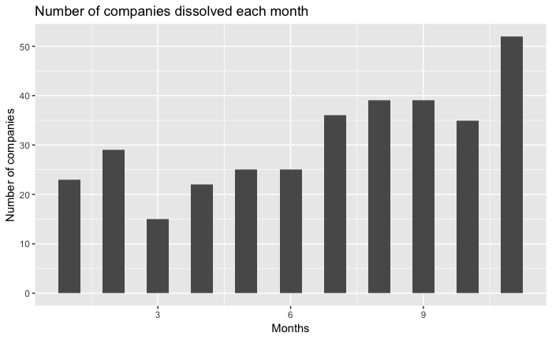

```r
qplot(dissolved18$month, geom="histogram",binwidth = 0.5, main="Number of companies dissolved each month",xlab="Months",ylab="Number of companies")
```

```r
test <- dissolved18 %>% group_by(month) %>% count()
test$n/sum(test$n)*100
```

```
 [1]  6.725146  8.479532  4.385965  6.725146  7.309942  7.309942 10.526316 11.403509 11.403509 10.233918 15.497076
```

```r
10.526316+11.403509+11.403509+10.233918+15.497076
```

```
[1] 59.06433
```

```r
dissolved18 %>% filter(!grepl("London|LONDON", address))
```

| index | word | name | number | company_type | linkCH | status | incorporation_date | dissolution_date | address | previous_name | ceased_on | effective_from | Year_Incorp | Year_Dissol | previous_effective_year | previous_ceased_year | duration_life | month |
| --- | --- | --- | --- | --- | --- | --- | --- | --- | --- | --- | --- | --- | --- | --- | --- | --- | --- | --- |
| 13 | bitcoin | BITCOIN BOX LIMITED | 10835427 | ltd | /company/10835427 | dissolved | 2017-06-26 | 2018-11-27 | 217 Stockport Road, Manchester, United Kingdom, M12 4DY | Empty | Empty | Empty | 2017 | 2018 | NA | NA | 519.0417 days | 11 |
| 21 | bitcoin | BITCOIN CORP LTD | 10536825 | ltd | /company/10536825 | dissolved | 2016-12-22 | 2018-05-29 | Parker Centre, Alfreton Road, Derby, United Kingdom, DE1 2JH | Empty | Empty | Empty | 2016 | 2018 | NA | NA | 523.0000 days | 5 |
| 25 | bitcoin | BITCOIN DREAM LIMITED | 10578681 | ltd | /company/10578681 | dissolved | 2017-01-23 | 2018-06-26 | 342 Modwen Road, Waters Edge Business Park, Salford, United Kingdom, M5 3EZ | Empty | Empty | Empty | 2017 | 2018 | NA | NA | 519.0000 days | 6 |
| 48 | bitcoin | BITCOIN HOURLY LIFE TIME LIMITED | 10672934 | ltd | /company/10672934 | dissolved | 2017-03-15 | 2018-08-21 | 132 High Street, Purley, United Kingdom, CR8 2AD | Empty | Empty | Empty | 2017 | 2018 | NA | NA | 524.0000 days | 8 |
| 49 | bitcoin | BITCOIN HOURS LTD | 10637199 | ltd | /company/10637199 | dissolved | 2017-02-24 | 2018-07-31 | 2 Sawley Road, Manchester, United Kingdom, M40 8DE | Empty | Empty | Empty | 2017 | 2018 | NA | NA | 522.0000 days | 7 |
| 56 | bitcoin | BITCOIN INVEST4U LTD | 10372977 | ltd | /company/10372977 | dissolved | 2016-09-13 | 2018-02-20 | 73 Francis Road, Birmingham, United Kingdom, B16 8SP | Empty | Empty | Empty | 2016 | 2018 | NA | NA | 525.0417 days | 2 |
| 57 | bitcoin | BITCOIN INVESTMENT LTD | 10748226 | ltd | /company/10748226 | dissolved | 2017-05-02 | 2018-10-09 | 50 Clarendon Street, Nottingham, United Kingdom, NG1 5HR | Empty | Empty | Empty | 2017 | 2018 | NA | NA | 525.0417 days | 10 |
| 60 | bitcoin | BITCOIN INVESTORS LTD | 10661311 | ltd | /company/10661311 | dissolved | 2017-03-09 | 2018-08-14 | Peter House, Oxford Street, Manchester, England, M1 5AN | Empty | Empty | Empty | 2017 | 2018 | NA | NA | 523.0000 days | 8 |
| 63 | bitcoin | BITCOIN LEAGUE LIMITED | 10498221 | ltd | /company/10498221 | dissolved | 2016-11-25 | 2018-05-01 | 185 Broad Street, Birmingham, West Midlands, United Kingdom, B15 1DT | Empty | Empty | Empty | 2016 | 2018 | NA | NA | 522.0000 days | 5 |
| 65 | bitcoin | BITCOIN LENDING SUPPORT SERVICES LTD | 10847516 | ltd | /company/10847516 | dissolved | 2017-07-03 | 2018-10-30 | Henhams Caxton Place Court Lane, Hadlow, Tonbridge, United Kingdom, TN11 0JU | Empty | Empty | Empty | 2017 | 2018 | NA | NA | 484.0417 days | 10 |

[output cut: 140 more lines]

```r
dissolved18 %>% group_by(Year_Incorp) %>% count()
```

| Year_Incorp | n |
| --- | --- |
| 1979 | 1 |
| 1993 | 1 |
| 1997 | 1 |
| 1999 | 2 |
| 2002 | 1 |
| 2008 | 1 |
| 2009 | 1 |
| 2010 | 1 |
| 2012 | 2 |
| 2013 | 3 |

[output cut: 5 more lines]

```r
(105+206)/340
```

```
[1] 0.9147059
```

```r
206/340
```

```
[1] 0.6058824
```

91% of the companies dissolved in 2018 were created between 2016 and 2017. 60% of the companies dissolved or in liquidation in 2018 were incorporated to the Companies House register in 2017.

```r
write.csv(dissolved18, "dissolved18_final.csv")
write.csv(dissolved18 %>% filter(!grepl("London|LONDON", address)),"outsidelondon.csv")
```

## Ceased companies still in active

```r
total %>% filter(status == "active" & previous_name !="Empty" & previous_ceased_year == 2018 & !grepl("CRYPTOGRAPHY|UK YIRENJIAREN BIZ CENTRE|BRAND AND TECHNOLOGY|LEISURE|ABK CRYPTO HOLDINGS|LABS|GLOBAL TV|JUST ABOUT|TOWARDS BLOCKCHAIN|COIN EQUITY|MOVIE", name)) %>% mutate(duration_life = difftime(ceased_on, effective_from, units = c("days"))) %>% arrange(duration_life) %>% select(name,previous_name,ceased_on)
```

| name | previous_name | ceased_on |
| --- | --- | --- |
| STAPLETON CAPITAL LIMITED | BLOCKCHAIN WORLDWIDE LIMITED | 2018-01-19 |
| COIN PRIVATE FINANCE(NO1) LIMITED | CASTLEMAIN LIMITED | 2018-09-12 |
| LA VEHICLE SERVICES LIMITED | LA BITCOINS LTD | 2018-08-15 |
| COLUMBUS FINANCIAL ADVISORY LTD | COLUMBUS BLOCKCHAIN MANAGEMENT LIMITED | 2018-01-22 |
| IVOIRE CONSULTING LIMITED | IVOIRE CRYPTO LIMITED | 2018-08-15 |
| BELBAR LIMITED | CRYPTO RIGS LIMITED | 2018-02-06 |
| COLLECTIVE CONSULTING COURSES LIMITED | CRYPTO COLLECTIVE LIMITED | 2018-02-16 |
| FHB RENEWABLE ENERGY LTD | CRYPTOMAIN LTD | 2018-07-12 |
| LITECASH LTD | HONEYCOMB BLOCKCHAIN LTD | 2018-11-21 |
| UBICORN LIMITED | BITCOINUKMEDIA LTD | 2018-02-05 |

[output cut: 44 more lines]

54 companies were ceased on 2018 and changed their names. 26 of those companies were also registered in Companies House during 2018

.

```r
write.csv(total %>% filter(status == "active" & previous_name !="Empty" & previous_ceased_year == 2018 & !grepl("CRYPTOGRAPHY|UK YIRENJIAREN BIZ CENTRE|BRAND AND TECHNOLOGY|LEISURE|ABK CRYPTO HOLDINGS|LABS|GLOBAL TV|JUST ABOUT|TOWARDS BLOCKCHAIN|COIN EQUITY|MOVIE", name)&Year_Incorp==2018) %>% mutate(duration_life = difftime(ceased_on, effective_from, units = c("days"))) %>% arrange(duration_life), "ceased.csv")
```

## Creating companies

```r
total %>% filter(Year_Incorp=="2017" & status == "dissolved") %>% group_by(Year_Dissol) %>% count()
```

| Year_Dissol | n |
| --- | --- |
| 2017 | 4 |
| 2018 | 208 |

Around 800 new companies related to bitcoins were registered in both years, 2017 and 2018. Almost all of those created in 2018 are still active, but one in four of those created in 2017 has been dissolved the vast majority during 2018.

```r
212/808
```

```
[1] 0.2623762
```

```r
unique(total$status)
```

```
[1] "active"         "dissolved"      "administration" "liquidation"    "open"
```

## Decemeber 2017

```r
total %>% filter(grepl("2017-12",dissolution_date) & status == "dissolved") %>% select(name, status,incorporation_date,dissolution_date)
```

| name | status | incorporation_date | dissolution_date |
| --- | --- | --- | --- |
| CRYPTONIUM LIMITED | dissolved | 2016-07-12 | 2017-12-19 |
| BTCEXCEL TRADING & INVESTMENTS LTD | dissolved | 2016-07-05 | 2017-12-05 |
| BTCO SPORTS OILS LTD | dissolved | 2016-09-08 | 2017-12-05 |
| DIGITAL FOREIGN CURRENCY LTD | dissolved | 2015-08-18 | 2017-12-05 |

```r
write.csv(total %>% filter(grepl("2017-12",dissolution_date) & status == "dissolved"),"december17.csv")
```